# Zadanie 3 - raport

Ewa Baranowska, Marta Jóźwik

31 marca 2017

# 1 Dodawanie wag do zbioru

## 1.1 Wybieranie wag ze zbioru z kwestionariuszem

Ze zbioru Cy6_ms_cmb_stu_qqq.sav wybrałyśmy przy pomocy skryptu SAS-owego Z0_QQQ_wagi.sas kolumny z wagami (zmienne: W_FSTUWT oraz W_FSTURWT1:W_FSTURWT80) wraz z odpowiednimi kolumnami-kluczami (CNTSCHID oraz CNTSTUID). W wyniku wykonania tego skryptu został utworzony plik CY6_MS_CMB_STU_QQQ_wagi.csv zawierający 447400 obserwacji oraz 83 zmienne:

```r
library(knitr)
wagi <- read.csv("CY6_MS_CMB_STU_QQQ_wagi.csv")
kable(head(wagi[,c(1:7)],5))
```

| CNTSCHID | CNTSTUID | W_FSTUWT | W_FSTURWT1 | W_FSTURWT2 | W_FSTURWT3 | W_FSTURWT4 |
| --- | --- | --- | --- | --- | --- | --- |
| 3600001 | 3610676 | 28.19991 | 38.41614 | 40.67887 | 39.73520 | 43.01364 |
| 3600001 | 3611874 | 28.19991 | 38.41614 | 40.67887 | 39.73520 | 43.01364 |
| 3600001 | 3601769 | 28.19991 | 38.41614 | 40.67887 | 39.73520 | 43.01364 |
| 3600001 | 3605996 | 28.19991 | 38.41614 | 40.67887 | 39.73520 | 43.01364 |
| 3600001 | 3608147 | 33.44862 | 44.75499 | 48.22453 | 44.75499 | 50.58734 |

## 1.2 Dodawanie wag do zbiorów głównych i tworzenie plików ze statystykami

Wykorzystując wcześniej stworzony zbiór dołączono kolumny z wagami do głównych zbiorów: Z0_matem.rda, Z0_read.rda oraz Z0_science.rda, tworząc zbiory Z0_matem_w.rda, Z0_read_w.rda oraz Z0_science_w.rda o 99 kolumnach.

Dodatkowo utworzono dla każdego ze zbiorów (działów) pomocniczy dokument xlsowy, w którym w oddzielnych arkuszach umieszczono ważone statystyki dla każdego z pytań z odpowiedniego działu dla każdego kraju oraz łączne statystyki dla całego pytania (CNT = TOTAL).

Przykład takiego pojedynczego arkusza:

```r
library(readxl)
podglad <- read_excel("stat_matem_3.xlsx", sheet = "M00GQ01")
kable(head(podglad,10))
```

| CNT | item_short | ProcFullCredit | ProcNoCredit | N | TimeAvgMin | TimeMedMin | TimeMinMin | TimeMaxMin |
| --- | --- | --- | --- | --- | --- | --- | --- | --- |
| TOTAL | M00GQ01 | 6.730839 | 93.26916 | 49388 | 2.362567 | 2.029950 | 0.0185333 | 34.611283 |
| JPN | M00GQ01 | 21.648646 | 78.35135 | 710 | 2.203000 | 2.029050 | 0.1383667 | 7.836333 |
| TAP | M00GQ01 | 17.651598 | 82.34840 | 887 | 2.088974 | 1.833317 | 0.0761167 | 8.916500 |
| SGP | M00GQ01 | 17.439070 | 82.56093 | 708 | 1.888042 | 1.602083 | 0.1028000 | 17.482383 |
| CHE | M00GQ01 | 17.433723 | 82.56628 | 929 | 2.510147 | 2.220017 | 0.0569833 | 12.481950 |
| QCH | M00GQ01 | 13.754935 | 86.24507 | 1122 | 2.571105 | 2.236817 | 0.0210333 | 13.758600 |
| HKG | M00GQ01 | 12.663616 | 87.33638 | 616 | 1.782732 | 1.504117 | 0.1183167 | 13.118017 |
| SWE | M00GQ01 | 12.286447 | 87.71355 | 535 | 3.015930 | 2.580500 | 0.1109833 | 16.133267 |
| KOR | M00GQ01 | 11.567904 | 88.43210 | 626 | 1.690224 | 1.497967 | 0.0694000 | 8.138767 |
| POL | M00GQ01 | 10.723785 | 89.27621 | 703 | 2.556024 | 2.213100 | 0.1706500 | 14.724767 |

Obie czynności zostały wykonane przy użyciu skryptu Z3_1.r.

# 2 Wizualizacja

## 2.1 Część 1 - wstępna analiza czasów i odpowiedzi dla pytań

Patrząc na średnie czasy rozwiązywania różnych rodzajów zadań widać, że zarówno ogólnie jak i w rozbiciu na poszczególne kontynenty średni czas rozwiązywania zadań z matematyki jest najdłuższy, a czytanie i nauki ścisłe mają podobny średni czas.

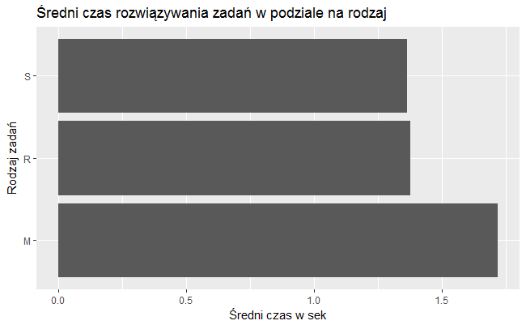

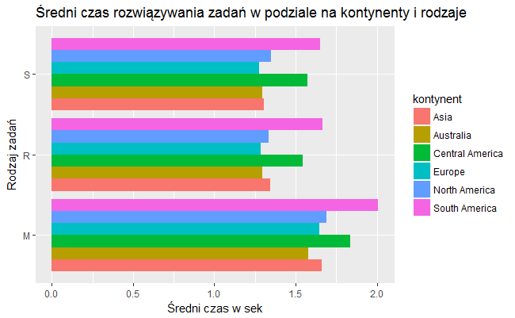

Zobaczmy teraz jak wygląda średni czas rozwiązywania 1 zadania w podziale na kraje.

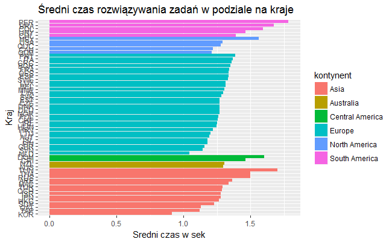

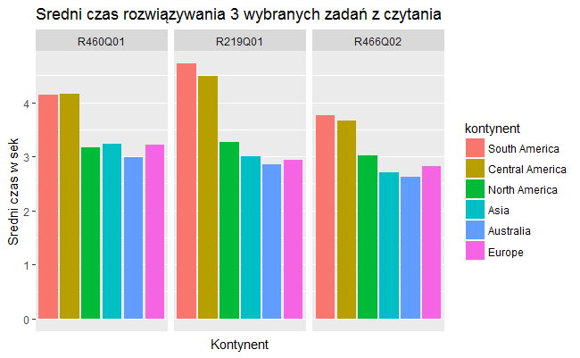

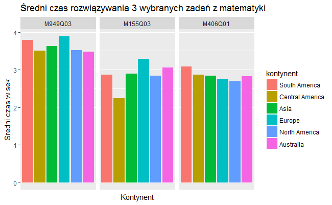

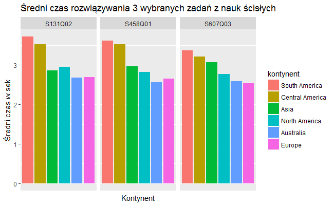

Teraz obejrzyjmy te wykresy dla kilku wybranych krajów:

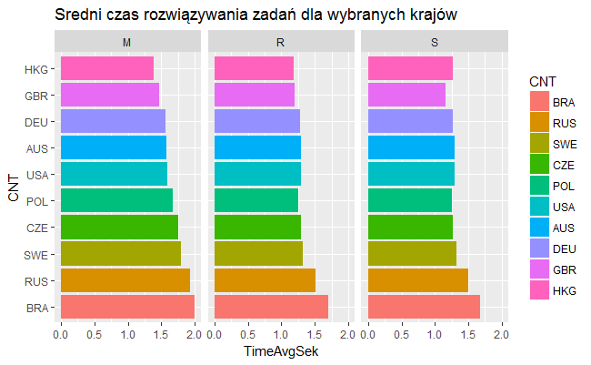

Można zauważyć, że ‘czołówka’ i ‘koniec stawki’ znów pozostają prawie takie same niezależnie od rodzaju zadania.

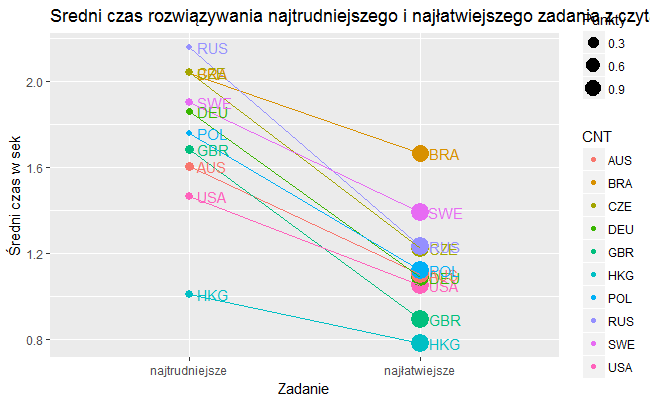

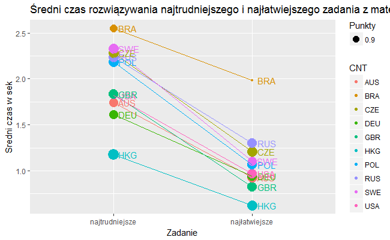

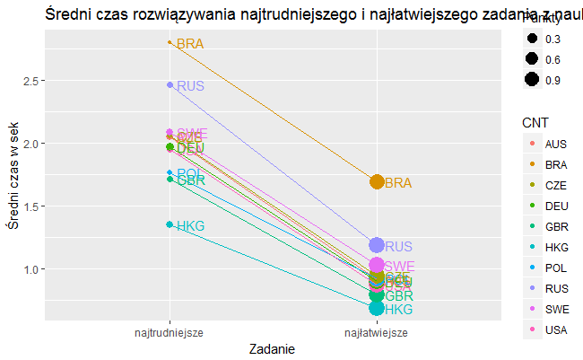

Warto również przyjrzeć się wpływowi płci na czasy rozwiązywania zadań. Wydaje się, że dziewczynki zwykle rozwiązują zadania z czytania i nauk ścisłych dłużej niż chłopcy, matematyka jest rozwiązywana w podobnym czasie.

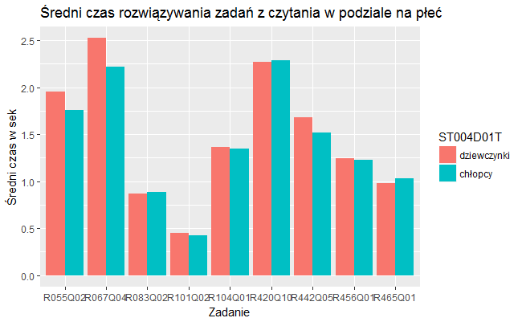

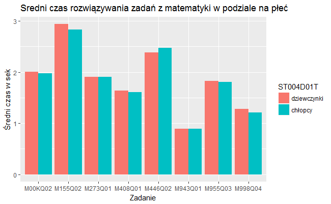

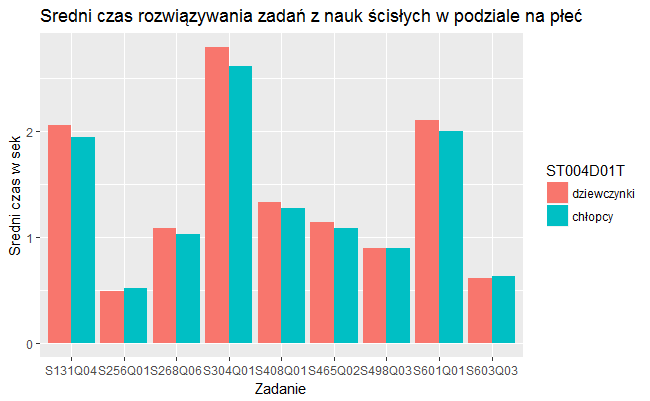

Również ciekawe będzie spojrzenie na średnie czasy przy różnych zadeklarowanych poziomach zdenerwowania. Wydaje się, że ci którzy mało sie denerwowali powinni rozwiązywać zadania szybciej, jednak w większości przypadków różnice są tak niewielkie, że możemy własciwie mówić o braku różnic.

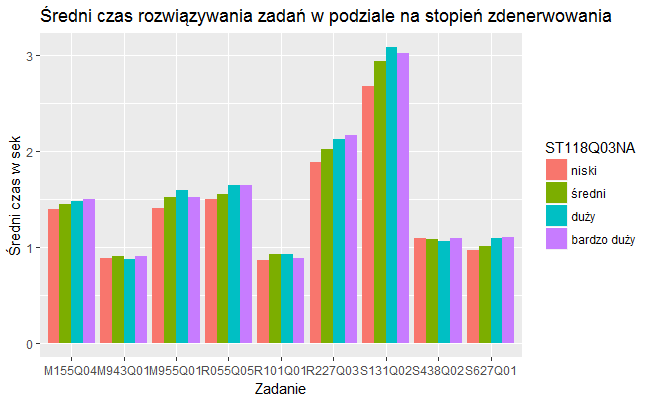

## 2.2 Część 2 - wyniki w działach M R i S w podziale na kraje i płeć

Przy pomocy skryptu Z3_2_plec.R przygotowano odpowiednie dane potrzebne do wygenerowania 3 wykresów dot.poprawnych odpowiedzi na pytania z 3 działów w podziale na płeć i kraje. Wygenerowane dane miały postać

```
  a) ramki danych zawierającej średnie ważone procenty poprawnych odpowiedzi w podziale na płeć dla danego działu np.
```

```r
load("total.rda")
kable(total)
```

| ST004D01T | ProcFullCredit |
| --- | --- |
| 1 | 41.57373 |
| 2 | 44.54091 |

```
  b) ramki danych zawierającej dla danego działu dla wszystkich krajów:

  CNT - skrótowa nazwa kraju

  nazwa - pełna nazwa kraju

  GII - indeks nierówności płci (ze strony http://hdr.undp.org/en/composite/GII)

  M - średni ważony procent popr. odpowiedzi dla mężczyzn

  F - średni ważony procent popr. odpowiedzi dla kobiet

  czyIstotny - wynik dwustronnego testu równości powyższych proporcji (na poziomie alfa = 0.05)
```

```r
load("dane_plec.rda")
kable(head(dane_plec,8))
```

[output not shown]

Odchylenie standardowe użyte przy liczeniu statystyki testowej testu równości proprocji zostało policzone przy użyciu wzoru:

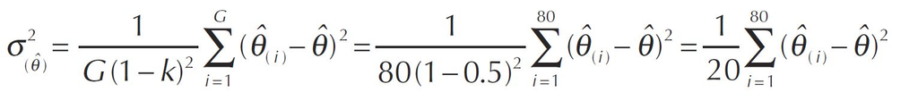

Gotowe wykresy interaktywne są dostępne w plikach: “wykres matem.html”, “wykres read.html”, “wykres science.html”. Zostały one stworzone na podstawie powyższych 2 ramek danych (po wcześniejszym ich przekonwertowaniu do obiektów/tablic JS) przy użyciu biblioteki D3.js.

Wersja statyczna takiej grafiki dla działu matematycznego wygląda następująco (w wersji interaktywnej dostępne są tooltipy po najechaniu na kółko lub kwadrat, pokazujące wartości zmiennych użytych do wygenerowania danego punktu):

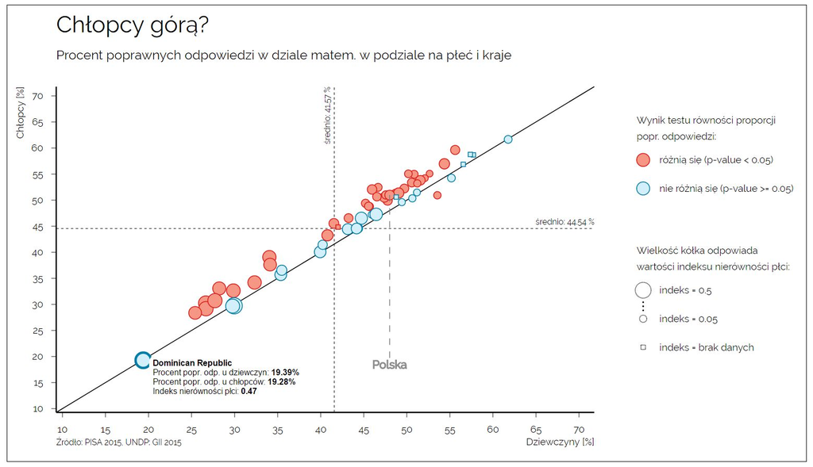

Na wykresie na osi poziomej umieszczono procent poprawnych odpowiedzi na pytania z działu matematycznego dla dziewczyn, a na osi pionowej analogiczne liczby dla chłopców. Kółkami (lub kwadracikami) zaznaczono te proprocje dla poszczególnych krajów. Kolor kształtu zależy od wyniku testu równości proporcji popr. odpowiedzi, natomiast kształt i wielkość punktów zależy od indeksu GII (indeksu nierówności płci), udostępnionego przez ONZ (kwadrat oznacza brak danych na temat GII dla danego państwa). Dodatkowo na wykresie umieszczono adnotację pozwalającą szybko zlokalizować Polskę oraz linie ogólnych ważonych średnich procentów popr. odpowiedzi dla obu płci, aby można był np. ocenić czy dziewczynki i/lub chłopcy w Polsce radzą sobie lepiej czy gorzej od średniej.

Wnioski:

[output not shown]

## 2.3 Część 3 - czasy odp. i proc. popr. odp. w działach M R i S

Przy pomocy skryptu Z3_3.R przygotowano odpowiednie dane potrzebne do wygenerowania 3 wykresów dot. czasów odpowiedzi oraz procentów poprawnych odpowiedzi na pytania z 3 działów. Wygenerowane dane miały postać:

```
  a) ramki danych zawierającej dla danego działu

  item_short - nazwa pytania

  VARLABEL - treść pytania z Codebook

  ProcFullCredit - ważony procent poprawnych odpowiedzi na dane pytanie

  N - ilość odpowiedzi na dane pytanie

  TimeAvgMin - średni ważony czas odpowiedzi na pytania w min

  std - odchylenie standardowe proc. popr. odp. wśród krajów odpowiadających na dane pytanie

  rankingPolska - wynik Polski dla danego pytania (pozycja)

  top1 - kraj, który osiągnął najlepszy wynik dla danego pytania

  top2 - kraj, który osiągnął drugi najlepszy wynik dla danego pytania

  top3 - kraj, który osiągnął trzeci najlepszy wynik dla danego pytania
```

```r
load(file="daneMatem_pytania.rda")
kable(head(daneMatem,8))
```

| item_short | ProcFullCredit | N | TimeAvgMin | VARLABEL | std | rankingPolska | top1 | top2 | top3 |
| --- | --- | --- | --- | --- | --- | --- | --- | --- | --- |
| M00GQ01 | 6.730839 | 49388 | 2.362567 | Advertising Column - Q01 | 4.752516 | 9 | JPN | TAP | SGP |
| M00KQ02 | 11.319155 | 47734 | 1.992809 | Wheelchair Basketball - Q02 | 7.540330 | 13 | QCH | SGP | HKG |
| M033Q01 | 74.284375 | 52702 | 1.014022 | A View Room - Q01 | 10.189375 | 36 | CHE | DNK | JPN |
| M034Q01 | 31.600048 | 48752 | 1.860019 | Bricks - Q01 | 12.387135 | 23 | MAC | JPN | SGP |
| M155Q01 | 64.556499 | 48689 | 1.361685 | Population Pyramids - Q01 | 12.468226 | 41 | SGP | EST | MAC |
| M155Q02 | 49.572456 | 44917 | 2.887815 | Population Pyramids - Q02 | 15.646769 | 25 | HKG | SGP | NLD |
| M155Q03 | 16.175312 | 37770 | 2.961798 | Population Pyramids - Q03 | 6.718545 | 8 | SGP | JPN | QCH |
| M155Q04 | 47.400529 | 51557 | 1.465325 | Population Pyramids - Q04 | 11.875754 | 33 | FIN | MAC | FRA |

Gotowe wykresy interaktywne dostępne są w plikach: wykres_matem_pytania.html, wykres_read_pytania.html, wykres_science_pytania.html. Zostały one stworzone na podstawie ramek danych powyższego typu (po wcześniejszym ich przekonwertowaniu do obiektów/tablic JS) przy użyciu biblioteki D3.js.

Wersja statyczna takiego wykresu dla działu matematycznego wygląda następująco (w wersji interaktywnej dostępne są tooltipy po najechaniu na kółko, pokazujące wartości zmiennych użytych do wygenerowania danego punktu):

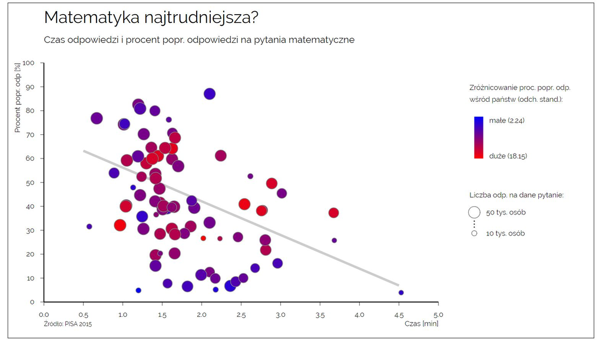

Na wykresie na osi poziomej umieszczono czas odpowiedzi na poszczególne pytania w min, na osi pionowje procent poprawnych odpowiedzi. Kółkami zaznaczono poszczególne pytania. Kolor kółka jest zależny od wielkości odchylenia standardowego dla danego pytania, liczonego po procentach poprawnych odpowiedzi dla danego pytania dla różnych państw. Wielkość kółka zależy od liczby osób odpowiadających na dane pytanie.

Wnioski:

```
     pytania różniły się między sobą średnim czasem odpowiedzi (od 0.5 do 4.5 min)

     pytania różniły się między sobą trudnością (patrząc po proc. popr. odpowiedzi

     pytania różniły się między sobą ilością wystąpień (nie każde pytanie zostało zadane uczniom mniej więcej tyle samo razy)

     pytania miały zróżnicowaną trudność dla różnych krajów, te bardzo łatwe i te bardzo trudne były w miarę dla wszystkich łatwe i trudne; pytania o średniej trudności miały największy zróżnicowanie wyników krajów

     średnie czasy pytań przyrodniczych nie przekraczają 3 min

     dla pytań z czytania trend zależności między czasem odp. a procentem popr. odp. okazuje się najmniejszy, nie wydaje się, żeby wraz ze wzrostem czasu poświęconego na zadanie, malał procent popr. odpowiedzi; wyraźniejsze trendy występują dla pytani przyrodniczych i matematycznych
```

# 3 Skrypty:

## 3.1 Z0_QQQ_wagi.sas

```r
/*********************************************************
importowanie pliku: Cy6_ms_cmb_stu_qqq.sav

folder_IN - sciezka do folderu zawierajacego plik Cy6_ms_cmb_stu_qqq.sav
folder_OUT - sciezka do folderu do zapisu pliku wyjściowego
***********************************************************/

%let folder_IN = C:\Users\E540\Desktop\PISA 2015\dokumentacja\;
%let folder_OUT = C:\Users\E540\Desktop\PISA 2015\zadanie0\;

proc import out=work.CY6_MS_CMB_STU_QQQ_wagi
  datafile = "&folder_IN.Cy6_ms_cmb_stu_qqq.sav"
  dbms = SAV replace;
run;

/*********************************************************
wybor odpowiednich kolumn i wierszy
***********************************************************/

data CY6_MS_CMB_STU_QQQ_wagi;
    set CY6_MS_CMB_STU_QQQ_wagi ( keep =
                                  CNTSCHID
                                  CNTSTUID
                                  W_FSTUWT
                                  W_FSTURWT:
                                  ADMINMODE
                              where = (ADMINMODE = 2)
                            );
run;

/*********************************************************
kasowanie formatów ze zmiennych
***********************************************************/

proc datasets lib=work nolist;
    modify CY6_MS_CMB_STU_QQQ_wagi;
    format _all_;
    informat _all_;
quit;
run;

/*********************************************************
odrzucenie zbędnej kolumny
***********************************************************/

data CY6_MS_CMB_STU_QQQ_wagi;
    set CY6_MS_CMB_STU_QQQ_wagi(drop = adminmode);
run;

/*********************************************************
eksportowanie gotowego zbioru do CY6_MS_CMB_STU_QQQ_wagi.csv
***********************************************************/

proc export data=CY6_MS_CMB_STU_QQQ_wagi
    outfile = "&folder_OUT.CY6_MS_CMB_STU_QQQ_wagi.csv"
    dbms = csv
    replace;
run;
```

## 3.2 Z3_1.r

```r
############################################################################
################ dodawanie wag do zbioru
############################################################################
setwd("C:/Users/E540/Desktop/PISA 2015/zadanie0")
load("Z0_matem.rda")
load("Z0_read.rda")
load("Z0_science.rda")
wagi <- read.csv("CY6_MS_CMB_STU_QQQ_wagi.csv")
memory.limit(200000)
Sys.setenv("R_ZIPCMD" = "C:/Rtools/bin/zip.exe") # writeWorkbook

Z3_statystyki <- function(zbior_in = Z0_matem, zbior_wagi=wagi, stat_out = "stat_matem.xlsx"){

   require(dplyr)
   require(isotone) # do wazonej mediany
   require(openxlsx)
   require(data.table)

   # dolaczanie wag do zbioru i zapis danych wraz z wagami
   zbior_in <- data.table(zbior_in)
   zbior_wagi <- data.table(zbior_wagi)
   setkey(zbior_in, CNTSCHID, CNTSTUID)
   setkey(zbior_wagi, CNTSCHID, CNTSTUID)
   zbior_in <- as.data.frame(zbior_wagi[zbior_in])
   cat("Zmergowano zbior z wagami","\n")



   # statystyki dla calego pytania

   zbior_in %>% group_by(item_short) %>% summarise( suma_pytanie = sum(W_FSTUWT),
                                                    ProcFullCredit = sum( W_FSTUWT[result == 3] ) * 100 / suma_pytanie,
                                                    ProcNoCredit = sum( W_FSTUWT[result == 1] )  * 100 / suma_pytanie,
                                                    N = n(),
                                                    TimeAvgMin = weighted.mean(timing/60000, W_FSTUWT),
                                                    TimeMedMin= weighted.median(timing/60000, W_FSTUWT),
                                                    TimeMinMin = min(timing)/60000,
                                                    TimeMaxMin = max(timing)/60000
   )  %>%
      select(-suma_pytanie) -> per_pytanie

   # dodanie kolumnt CNT = "TOTAL"
   per_pytanie <- cbind(CNT="TOTAL",per_pytanie)
   per_pytanie$CNT <- as.character(per_pytanie$CNT)

   # statystyki per pytanie per kraj

   zbior_in %>% group_by(CNT, item_short) %>% summarise( suma_pytanie = sum(W_FSTUWT),
                                                         ProcFullCredit = sum( W_FSTUWT[result == 3] ) * 100 / suma_pytanie,
                                                         ProcNoCredit = sum( W_FSTUWT[result == 1] )  * 100 / suma_pytanie,
                                                         N = n(),
                                                         TimeAvgMin = weighted.mean(timing/60000, W_FSTUWT),
                                                         TimeMedMin= weighted.median(timing/60000, W_FSTUWT),
                                                         TimeMinMin = min(timing)/60000,
                                                         TimeMaxMin = max(timing)/60000
   ) %>% select(-suma_pytanie) %>%
      arrange(item_short, desc(ProcFullCredit))-> per_kraj

   # zapis statystyk do pliku
   pytania <- sort(unique(zbior_in$item_short))
   n_pytania <- length(pytania)

   wb <- createWorkbook()

   for(i in 1:n_pytania){
      cat("Zapisano ", i, "/", n_pytania, "pytan \n")
      dane <- bind_rows(per_pytanie %>% filter(item_short == pytania[i]),
                        per_kraj %>% filter(item_short == pytania[i]))
      addWorksheet(wb, pytania[i])
      writeData(wb, sheet = pytania[i], x = dane)
   }

   saveWorkbook(wb, file=stat_out, overwrite = FALSE)


   return(zbior_in)

}

Z0_matem <- Z3_statystyki(zbior_in = Z0_matem, zbior_wagi = wagi, stat_out = "stat_matem_3.xlsx")
save(Z0_matem, file="Z0_matem_w.rda")
rm(Z0_matem)

Z0_read <- Z3_statystyki(zbior_in = Z0_read, zbior_wagi = wagi, stat_out = "stat_read_3.xlsx")
save(Z0_read, file="Z0_read_w.rda")
rm(Z0_read)

Z0_science <- Z3_statystyki(zbior_in = Z0_science, zbior_wagi = wagi, stat_out = "stat_science_3.xlsx")
save(Z0_science, file="Z0_science_w.rda")
rm(Z0_science)
```

## 3.3 Z3_2_plec.R

```r
setwd("C:/Users/E540/Desktop/PISA 2015/zadanie0")
load("Z0_matem_w.rda")
load("Z0_read_w.rda")
load("Z0_science_w.rda")
GII <- read.csv2("GII.csv", header = T, stringsAsFactors = F)
memory.limit(200000)


library(jsonlite)


daneDoWykresowPlec <- function(zbior, indeks_GII){

   require(dplyr)
   require(tidyr)

   # statystyki ogolne poprawnych odpowiedzi w podziale na plec
   zbior %>% group_by(ST004D01T) %>%
      summarise( ProcFullCredit = sum( W_FSTUWT[result == 3] ) * 100 /  sum(W_FSTUWT)) -> total



   # statystyki poprawnych odpowiedzi w podziale na plec per kraj
   zbior %>% group_by(CNT, ST004D01T) %>%
      summarise( ProcFullCredit = sum( W_FSTUWT[result == 3] ) * 100 / sum(W_FSTUWT)) %>% spread(ST004D01T,ProcFullCredit) -> per_kraj

   colnames(per_kraj) <-c("CNT", "F", "M")

   # kolumna odpowiadajaca za roznice miedzy plciami
   per_kraj$ile_roznicy <- per_kraj$F -per_kraj$M

   ######################## obliczanie  ważonych procentów dla każdego kraju

   # liczenie dla kolumn wagowych sumy wag
   zbior %>% select(-CNTSCHID, -CNTSTUID, -BOOKID, -klaster, -item_short, -CBASCI, -ST118Q01NA, -ST118Q02NA, -ST118Q03NA,
                    -ST118Q04NA, -ST118Q05NA, -item, -n.actions, -timing, -pozycja, -result) %>% group_by(CNT, ST004D01T) %>%
      summarise_each(funs(sum)) %>%
      gather(key=wagi, value=sumy_razem,-CNT, -ST004D01T)-> wazone

   # liczenie dla kolumn wagowych sumy wag dla poprawnych odpowiedzi
   zbior %>% filter(result == 3) %>%
      select(-CNTSCHID, -CNTSTUID, -BOOKID, -klaster, -item_short, -CBASCI, -ST118Q01NA, -ST118Q02NA, -ST118Q03NA,
                    -ST118Q04NA, -ST118Q05NA, -item, -n.actions, -timing, -pozycja, -result) %>% group_by(CNT, ST004D01T) %>%
      summarise_all( funs(sum) ) %>%
      gather(key=wagi, value=sumy_czesc,-CNT, -ST004D01T)-> wazone2

   wazone <- merge(wazone2, wazone, by=c("CNT", "ST004D01T", "wagi"))

   # liczenie procentu ważonego dla kazdego panstwa, plci i wagi
   wazone %>% group_by(CNT, ST004D01T, wagi) %>% summarise(procent = sumy_czesc*100/sumy_razem
                                                           ) %>% spread(ST004D01T,procent) -> wazone

   colnames(wazone) <-c("CNT","wagi", "F", "M")

   # liczenie roznicy procentu miedzy plciami dla kazdego kraju i wagi
   wazone %>% group_by(CNT, wagi) %>% mutate( roznica = F - M) -> wazone

   # obliczanie odchylenia standardowego na podstawie 80 wag
   wazone %>% group_by(CNT) %>% summarise(

      std = sqrt((1/20)*sum( (roznica[wagi=="W_FSTUWT"] - roznica )^2  ))

   ) -> wazone

   # dodanie odchylenia do glownego zbioru
   per_kraj <- merge(per_kraj, wazone,all.x=T, by=c("CNT"))
   rm(wazone)

   # obliczanie statystyki testowej
   # sprawdzanie istotności testu na poziomie 0.05 (dwustronny)
   per_kraj %>% mutate(z= ile_roznicy/std,
                       czyIstotny = (z < qnorm(0.025)) | (z  > qnorm(0.975) ) ) %>%
      select(-z,-std, -ile_roznicy) -> per_kraj


   # dolaczanie danych z indeksem GII
   indeks_GII$GII <- as.numeric(indeks_GII$GII)
   indeks_GII$GII <- ifelse(is.na(indeks_GII$GII),0,indeks_GII$GII) # wstawiamy 0 za NA

   per_kraj<- merge(per_kraj, indeks_GII, by=c("CNT"))


   return(list(total=total, dane=per_kraj))
}

#### dane matematyczne
daneMatem <- daneDoWykresowPlec(Z0_matem, GII)
rm(Z0_matem)
# zapis do struktur JavaScriptowych
jsonik <- toJSON(daneMatem$dane)
total <- toJSON(daneMatem$total$ProcFullCredit)

#### dane czytelnicze
daneRead <- daneDoWykresowPlec(Z0_read, GII)
rm(Z0_read)
# zapis do struktur JavaScriptowych
jsonik <- toJSON(daneRead$dane)
total <- toJSON(daneRead$total$ProcFullCredit)

#### dane matematyczne
daneScience <- daneDoWykresowPlec(Z0_science, GII)
rm(Z0_science)
# zapis do struktur JavaScriptowych
jsonik <- toJSON(daneScience$dane)
total <- toJSON(daneScience$total$ProcFullCredit)
```

## 3.4 Z3_3.R

```r
library(readxl)
library(dplyr)
library(stringi)
library(jsonlite)
setwd("C:/Users/E540/Desktop/PISA 2015/zadanie0")

# funkcja do wczytywania wszystkich arkuszy excela w jedną ramkę danych
read_excel_allsheets <- function(filename) {

   sheets <- excel_sheets(filename)
   x <-    do.call("rbind",
                   lapply(sheets, function(X) read_excel(filename, sheet = X))
   )

   return(x)

}

# pliki ze statystykami
stat_matem <- read_excel_allsheets("stat_matem_3.xlsx")
stat_read <- read_excel_allsheets("stat_read_3.xlsx")
stat_science <- read_excel_allsheets("stat_science_3.xlsx")

#  wczytywanie nazw pytan z Codebook
codebook <- read_excel("Codebook_CMB.xlsx", sheet="Cognitive")
codebook %>% filter(!is.na(NAME)) %>% mutate(NAME = substr(NAME,2,8)) %>%
   select(NAME, VARLABEL)-> codebook

# usuwanie śmieci z nazw pytań
for(slowo in c("(Coded Response)", "(Timing)", "(Number of Actions)","(Scored Response)","(Raw Response)",
               "(Raw Paper Response)", "(Paper Scored Response)", "[Part A]", " [Part B]", " [Part C]",
               " [Part D]", "(Coded Paper Response)" ,  "[Part E]",
               " [Part F]", " [Part G]", "[Part H]", " [Part I]",
               "(Number of Trials)", "(Number of Selected Rows)", "(Number of Rows)", " (All Rows Correct)",
               "[1-L2]", "[1-L1]", " [2-L1]", "[3-L3]", "[2-L2]", "[1-L3]",
               " (Solar Panels) - Q02", " (Solar Panels) - Q07", " (Solar Panels) - Q08")){

   codebook$VARLABEL <- stri_replace_all_fixed(codebook$VARLABEL,
                                               pattern = slowo, "")

}

codebook$VARLABEL <- stri_replace_all_regex(codebook$VARLABEL,
                                            pattern = "[ABCDE] $", "")

codebook$VARLABEL <- trimws(codebook$VARLABEL)
codebook %>% distinct(NAME, VARLABEL) -> codebook
colnames(codebook) <- c("item_short", "VARLABEL")


# funkcja do tworzenia potrzebnych zmiennych
doWykresuPytania <- function(zbior, codebook){

   # licze odchylenie standardowe dla proc popr. odpow
   zbior %>% filter(CNT != "TOTAL") %>% group_by(item_short) %>% summarise(std =sqrt(var(ProcFullCredit))) -> odch_stand

   # licze pozycje Polski w kazdym pytaniu
   zbior %>% filter(CNT != "TOTAL") %>% group_by(item_short) %>% arrange(item_short,desc(ProcFullCredit)) %>%
            mutate(rankingWPytaniu = 1:n()) %>% filter(CNT == "POL") %>% select(item_short,rankingWPytaniu) %>%
      rename(rankingPolska =  rankingWPytaniu )-> top_Polska

   # wyciagam top3 krajów dla każdego pytania
   zbior %>% filter(CNT != "TOTAL") %>% group_by(item_short) %>% arrange(item_short,desc(ProcFullCredit)) %>%
      mutate(rankingWPytaniu = 1:n(),
             top1 = CNT[ rankingWPytaniu == 1],
             top2 = CNT[ rankingWPytaniu == 2],
             top3 = CNT[ rankingWPytaniu == 3]) %>% distinct(top1, top2, top3)-> top3

   # wybieram tylko ogolne statystyki
   zbior %>% filter(CNT == "TOTAL") %>% select(item_short, ProcFullCredit, N, TimeAvgMin) -> zbior

   # dodaje nazwe pytania
   zbior <- merge(zbior, codebook, all.x = T, by=c("item_short"))

   # dodaje poprzednio obliczone zmienne
   zbior <- merge(zbior, odch_stand, all.x = T, by=c("item_short"))
   zbior <- merge(zbior, top_Polska, all.x = T, by=c("item_short"))
   zbior <- merge(zbior, top3, all.x = T, by=c("item_short"))

   return(zbior)

}

daneMatem <- doWykresuPytania(stat_matem,codebook)
daneRead <- doWykresuPytania(stat_read,codebook)
daneScience <- doWykresuPytania(stat_science,codebook)

daneMatem <- toJSON(daneMatem)
daneRead <- toJSON(daneRead)
daneScience <- toJSON(daneScience)

#save(daneMatem, file="daneMatem_pytania.rda")
```